# R: Differential item functioning statistics

| DIF {mirt} | R Documentation |
| --- | --- |

## Differential item functioning statistics

### Description

This function runs the Wald and likelihood-ratio approaches for testing differential item functioning (DIF) with two or more groups. This is primarily a convenience wrapper to the `multipleGroup` function for performing standard DIF procedures. Independent models can be estimated in parallel by defining a parallel object with `mirtCluster`, which will help to decrease the run time. For best results, the baseline model should contain a set of 'anchor' items and have freely estimated hyper-parameters in the focal groups.

### Usage

```r
DIF(
  MGmodel,
  which.par,
  scheme = "add",
  items2test = 1:extract.mirt(MGmodel, "nitems"),
  groups2test = "all",
  seq_stat = "SABIC",
  Wald = FALSE,
  p.adjust = "none",
  pairwise = FALSE,
  return_models = FALSE,
  return_seq_model = FALSE,
  max_run = Inf,
  plotdif = FALSE,
  type = "trace",
  simplify = TRUE,
  verbose = TRUE,
  ...
)
```

### Arguments

[output not shown]

### Details

Generally, the pre-computed baseline model should have been configured with two estimation properties: 1) a set of 'anchor' items, where the anchor items have various parameters that have been constrained to be equal across the groups, and 2) contain freely estimated latent mean and variance terms in all but one group (the so-called 'reference' group). These two properties help to fix the metric of the groups so that item parameter estimates do not contain latent distribution characteristics.

### Value

a `mirt_df` object with the information-based criteria for DIF, though this may be changed to a list output when `return_models` or `simplify` are modified. As well, a silent `'DIF_coefficeints'` attribute is included to view the item parameter differences between the groups

### Author(s)

Phil Chalmers rphilip.chalmers@gmail.com

### References

Chalmers, R., P. (2012). mirt: A Multidimensional Item Response Theory Package for the R Environment. *Journal of Statistical Software, 48*(6), 1-29. [doi:10.18637/jss.v048.i06](https://doi.org/10.18637/jss.v048.i06)

Chalmers, R. P., Counsell, A., and Flora, D. B. (2016). It might not make a big DIF: Improved Differential Test Functioning statistics that account for sampling variability. *Educational and Psychological Measurement, 76*, 114-140. [doi:10.1177/0013164415584576](https://doi.org/10.1177/0013164415584576)

### See Also

`multipleGroup`, `DRF`

### Examples

```r
## No test:

# simulate data where group 2 has a smaller slopes and more extreme intercepts
set.seed(12345)
a1 <- a2 <- matrix(abs(rnorm(15,1,.3)), ncol=1)
d1 <- d2 <- matrix(rnorm(15,0,.7),ncol=1)
a2[1:2, ] <- a1[1:2, ]/3
d1[c(1,3), ] <- d2[c(1,3), ]/4
head(data.frame(a.group1 = a1, a.group2 = a2, d.group1 = d1, d.group2 = d2))
```

```
##    a.group1  a.group2    d.group1   d.group2
## 1 1.1756586 0.3918862  0.14295747  0.5718299
## 2 1.2128398 0.4042799 -0.62045026 -0.6204503
## 3 0.9672090 0.9672090 -0.05802608 -0.2321043
## 4 0.8639508 0.8639508  0.78449886  0.7844989
## 5 1.1817662 1.1817662  0.20910659  0.2091066
## 6 0.4546132 0.4546132  0.54573535  0.5457353
```

```r
itemtype <- rep('2PL', nrow(a1))
N <- 1000
dataset1 <- simdata(a1, d1, N, itemtype)
dataset2 <- simdata(a2, d2, N, itemtype, mu = .1, sigma = matrix(1.5))
dat <- rbind(dataset1, dataset2)
group <- c(rep('D1', N), rep('D2', N))

#### no anchors, all items tested for DIF by adding item constrains one item at a time.
# define a parallel cluster (optional) to help speed up internal functions
if(interactive()) mirtCluster()

# Information matrix with Oakes' identity (not controlling for latent group differences)
# NOTE: Without properly equating the groups the following example code is not testing for DIF,
     # but instead reflects a combination of DIF + latent-trait distribution effects
model <- multipleGroup(dat, 1, group, SE = TRUE)

# Likelihood-ratio test for DIF (as well as model information)
dif <- DIF(model, c('a1', 'd'))
```

```
## NOTE: No hyper-parameters were estimated in the DIF model.
##       For effective DIF testing, freeing the focal group hyper-parameters is recommended.
```

```r
dif
```

```
##         groups converged     AIC   SABIC      HQ     BIC     X2 df     p
## Item_1   D1,D2      TRUE -34.621 -29.773 -30.507 -23.419 38.621  2     0
## Item_2   D1,D2      TRUE -20.364 -15.516 -16.251  -9.162 24.364  2     0
## Item_3   D1,D2      TRUE -10.101  -5.253  -5.988   1.101 14.101  2 0.001
## Item_4   D1,D2      TRUE  -0.356   4.492   3.757  10.846  4.356  2 0.113
## Item_5   D1,D2      TRUE   0.968   5.815   5.081  12.169  3.032  2  0.22
## Item_6   D1,D2      TRUE   3.441   8.289   7.554  14.643  0.559  2 0.756
## Item_7   D1,D2      TRUE   3.340   8.188   7.453  14.542   0.66  2 0.719
## Item_8   D1,D2      TRUE  -2.371   2.477   1.742   8.831  6.371  2 0.041
## Item_9   D1,D2      TRUE   0.546   5.393   4.659  11.748  3.454  2 0.178
## Item_10  D1,D2      TRUE   3.215   8.062   7.328  14.416  0.785  2 0.675
## Item_11  D1,D2      TRUE  -4.853  -0.006  -0.740   6.348  8.853  2 0.012
## Item_12  D1,D2      TRUE   1.497   6.345   5.610  12.699  2.503  2 0.286
## Item_13  D1,D2      TRUE   1.854   6.702   5.967  13.056  2.146  2 0.342
## Item_14  D1,D2      TRUE  -4.350   0.498  -0.237   6.852   8.35  2 0.015
## Item_15  D1,D2      TRUE   3.831   8.679   7.944  15.033  0.169  2 0.919
```

```r
# function silently includes "DIF_coefficients" attribute to view
# the IRT parameters post-completion
extract.mirt(dif, "DIF_coefficients")
```

```
## $Item_1
##           a1         d g u
## D1 0.7472578 0.3483822 0 1
## D2 0.7472578 0.3483822 0 1
##
## $Item_2
##           a1          d g u
## D1 0.8277687 -0.6535244 0 1
## D2 0.8277687 -0.6535244 0 1
##
## $Item_3
##          a1          d g u
## D1 1.213165 -0.1452843 0 1
## D2 1.213165 -0.1452843 0 1
##
## $Item_4
##          a1         d g u
## D1 1.017216 0.9327436 0 1
## D2 1.017216 0.9327436 0 1
##
## $Item_5
##          a1         d g u
## D1 1.216819 0.1966309 0 1
## D2 1.216819 0.1966309 0 1
##
## $Item_6
##           a1        d g u
## D1 0.5196433 0.652555 0 1
## D2 0.5196433 0.652555 0 1
##
## $Item_7
##          a1        d g u
## D1 1.348864 1.016455 0 1
## D2 1.348864 1.016455 0 1
##
## $Item_8
##          a1          d g u
## D1 1.089472 -0.3447219 0 1
## D2 1.089472 -0.3447219 0 1
##
```

[output cut: 19 more lines]

```
##
## $Item_13
##          a1         d g u
## D1 1.389336 0.4619023 0 1
## D2 1.389336 0.4619023 0 1
##
## $Item_14
##          a1         d g u
## D1 1.294955 0.4870637 0 1
## D2 1.294955 0.4870637 0 1
##
## $Item_15
##           a1           d g u
## D1 0.8797218 -0.04575426 0 1
## D2 0.8797218 -0.04575426 0 1
```

```r
# same as above, but using Wald tests with Benjamini & Hochberg adjustment
DIF(model, c('a1', 'd'), Wald = TRUE, p.adjust = 'fdr')
```

```
## NOTE: No hyper-parameters were estimated in the DIF model.
##       For effective DIF testing, freeing the focal group hyper-parameters is recommended.
```

```
##         groups      W df     p adj_p
## Item_1   D1,D2 36.513  2     0 0.000
## Item_2   D1,D2 22.089  2     0 0.000
## Item_3   D1,D2 13.444  2 0.001 0.006
## Item_4   D1,D2  4.293  2 0.117 0.251
## Item_5   D1,D2  3.009  2 0.222 0.370
## Item_6   D1,D2  0.558  2 0.756 0.810
## Item_7   D1,D2  0.658  2  0.72 0.810
## Item_8   D1,D2  6.238  2 0.044 0.111
## Item_9   D1,D2  3.438  2 0.179 0.336
## Item_10  D1,D2  0.785  2 0.675 0.810
## Item_11  D1,D2  8.621  2 0.013 0.050
## Item_12  D1,D2  2.485  2 0.289 0.433
## Item_13  D1,D2  2.133  2 0.344 0.469
## Item_14  D1,D2  8.062  2 0.018 0.053
## Item_15  D1,D2  0.168  2 0.919 0.919
```

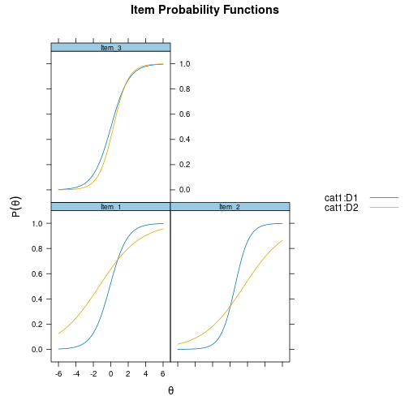

```r
# equate the groups by assuming the last 5 items have no DIF
itemnames <- colnames(dat)
model <- multipleGroup(dat, 1, group, SE = TRUE,
   invariance = c(itemnames[11:ncol(dat)], 'free_means', 'free_var'))

# test whether adding slopes and intercepts constraints results in DIF. Plot items showing DIF
resulta1d <- DIF(model, c('a1', 'd'), plotdif = TRUE, items2test=1:10)
```

```r
resulta1d
```

```
##         groups converged     AIC   SABIC      HQ     BIC    X2 df     p
## Item_1   D1,D2      TRUE -43.490 -38.642 -39.377 -32.288 47.49  2     0
## Item_2   D1,D2      TRUE -33.840 -28.993 -29.727 -22.638 37.84  2     0
## Item_3   D1,D2      TRUE  -5.497  -0.649  -1.384   5.705 9.497  2 0.009
## Item_4   D1,D2      TRUE   2.395   7.242   6.508  13.596 1.605  2 0.448
## Item_5   D1,D2      TRUE   3.140   7.988   7.253  14.342  0.86  2 0.651
## Item_6   D1,D2      TRUE   1.122   5.970   5.235  12.324 2.878  2 0.237
## Item_7   D1,D2      TRUE   3.083   7.931   7.196  14.285 0.917  2 0.632
## Item_8   D1,D2      TRUE   2.857   7.705   6.970  14.059 1.143  2 0.565
## Item_9   D1,D2      TRUE   3.674   8.521   7.787  14.875 0.326  2 0.849
## Item_10  D1,D2      TRUE   3.154   8.001   7.267  14.355 0.846  2 0.655
```

```r
# test whether adding only slope constraints results in DIF for all items
DIF(model, 'a1', items2test=1:10)
```

```
##         groups converged     AIC   SABIC      HQ     BIC     X2 df     p
## Item_1   D1,D2      TRUE -20.871 -18.447 -18.815 -15.270 22.871  1     0
## Item_2   D1,D2      TRUE -34.675 -32.252 -32.619 -29.075 36.675  1     0
## Item_3   D1,D2      TRUE   0.435   2.859   2.492   6.036  1.565  1 0.211
## Item_4   D1,D2      TRUE   1.980   4.404   4.036   7.581   0.02  1 0.887
## Item_5   D1,D2      TRUE   1.754   4.178   3.811   7.355  0.246  1  0.62
## Item_6   D1,D2      TRUE  -0.564   1.860   1.492   5.037  2.564  1 0.109
## Item_7   D1,D2      TRUE   1.093   3.517   3.150   6.694  0.907  1 0.341
## Item_8   D1,D2      TRUE   1.431   3.855   3.488   7.032  0.569  1 0.451
## Item_9   D1,D2      TRUE   1.863   4.287   3.920   7.464  0.137  1 0.712
## Item_10  D1,D2      TRUE   1.775   4.199   3.832   7.376  0.225  1 0.636
```

```r
# Determine whether it's a1 or d parameter causing DIF (could be joint, however)
(a1s <- DIF(model, 'a1', items2test = 1:3))
```

```
##        groups converged     AIC   SABIC      HQ     BIC     X2 df     p
## Item_1  D1,D2      TRUE -20.871 -18.447 -18.815 -15.270 22.871  1     0
## Item_2  D1,D2      TRUE -34.675 -32.252 -32.619 -29.075 36.675  1     0
## Item_3  D1,D2      TRUE   0.435   2.859   2.492   6.036  1.565  1 0.211
```

```r
(ds <- DIF(model, 'd', items2test = 1:3))
```

```
##        groups converged     AIC   SABIC      HQ     BIC     X2 df     p
## Item_1  D1,D2      TRUE -18.568 -16.145 -16.512 -12.968 20.568  1     0
## Item_2  D1,D2      TRUE   1.843   4.266   3.899   7.443  0.157  1 0.691
## Item_3  D1,D2      TRUE  -6.229  -3.805  -4.173  -0.628  8.229  1 0.004
```

```r
### drop down approach (freely estimating parameters across groups) when
### specifying a highly constrained model with estimated latent parameters
model_constrained <- multipleGroup(dat, 1, group,
  invariance = c(colnames(dat), 'free_means', 'free_var'))
dropdown <- DIF(model_constrained, c('a1', 'd'), scheme = 'drop')
dropdown
```

```
##         groups converged     AIC   SABIC      HQ     BIC     X2 df     p
## Item_1   D1,D2      TRUE -43.297 -38.450 -39.184 -32.096 47.297  2     0
## Item_2   D1,D2      TRUE -32.642 -27.794 -28.529 -21.440 36.642  2     0
## Item_3   D1,D2      TRUE -10.510  -5.662  -6.397   0.692  14.51  2 0.001
## Item_4   D1,D2      TRUE   1.885   6.733   5.998  13.087  2.115  2 0.347
## Item_5   D1,D2      TRUE   3.155   8.003   7.268  14.357  0.845  2 0.655
## Item_6   D1,D2      TRUE   1.914   6.761   6.027  13.116  2.086  2 0.352
## Item_7   D1,D2      TRUE   3.887   8.735   8.000  15.089  0.113  2 0.945
## Item_8   D1,D2      TRUE   0.703   5.550   4.816  11.905  3.297  2 0.192
## Item_9   D1,D2      TRUE   3.059   7.907   7.172  14.261  0.941  2 0.625
## Item_10  D1,D2      TRUE   3.631   8.479   7.744  14.833  0.369  2 0.832
## Item_11  D1,D2      TRUE  -0.765   4.083   3.348  10.437  4.765  2 0.092
## Item_12  D1,D2      TRUE   3.511   8.359   7.624  14.713  0.489  2 0.783
## Item_13  D1,D2      TRUE   3.416   8.263   7.529  14.618  0.584  2 0.747
## Item_14  D1,D2      TRUE  -0.690   4.157   3.423  10.511   4.69  2 0.096
## Item_15  D1,D2      TRUE   3.599   8.447   7.712  14.801  0.401  2 0.818
```

```r
# View silent "DIF_coefficients" attribute
extract.mirt(dropdown, "DIF_coefficients")
```

```
## $Item_1
##           a1         d g u
## D1 1.0070333 0.1008689 0 1
## D2 0.4519451 0.5696948 0 1
##
## $Item_2
##           a1          d g u
## D1 1.2404964 -0.7051772 0 1
## D2 0.4454868 -0.6639707 0 1
##
## $Item_3
##           a1           d g u
## D1 0.9753304 -0.02503532 0 1
## D2 1.3391630 -0.38511564 0 1
##
## $Item_4
##           a1         d g u
## D1 0.8791819 0.8382862 0 1
## D2 1.0156000 0.9950612 0 1
##
## $Item_5
##          a1         d g u
## D1 1.121611 0.1289459 0 1
## D2 1.174548 0.2229440 0 1
##
## $Item_6
##           a1         d g u
## D1 0.5623518 0.6822046 0 1
## D2 0.4157185 0.6026837 0 1
##
## $Item_7
##          a1         d g u
## D1 1.283799 1.0057393 0 1
## D2 1.237164 0.9681297 0 1
##
## $Item_8
##           a1          d g u
## D1 0.8938398 -0.3260637 0 1
## D2 1.1477262 -0.4254126 0 1
##
```

[output cut: 19 more lines]

```
##
## $Item_13
##          a1         d g u
## D1 1.236010 0.4387954 0 1
## D2 1.358438 0.4178786 0 1
##
## $Item_14
##          a1         d g u
## D1 1.042359 0.4541499 0 1
## D2 1.400256 0.4556638 0 1
##
## $Item_15
##           a1           d g u
## D1 0.8583058 -0.06114579 0 1
## D2 0.7771780 -0.06825570 0 1
```

```r
### sequential schemes (add constraints)

### sequential searches using SABIC as the selection criteria
# starting from completely different models
stepup <- DIF(model, c('a1', 'd'), scheme = 'add_sequential',
              items2test=1:10)
```

```
##
Checking for DIF in 3 more items
## Computing final DIF estimates...
```

```r
stepup
```

```
##        groups converged     AIC   SABIC      HQ     BIC     X2 df     p
## Item_1  D1,D2      TRUE -43.161 -38.314 -39.048 -31.959 47.161  2     0
## Item_2  D1,D2      TRUE -34.224 -29.377 -30.111 -23.022 38.224  2     0
## Item_3  D1,D2      TRUE  -7.368  -2.520  -3.255   3.834 11.368  2 0.003
```

```r
# step down procedure for highly constrained model
stepdown <- DIF(model_constrained, c('a1', 'd'), scheme = 'drop_sequential')
```

```
##
Checking for DIF in 12 more items
## Computing final DIF estimates...
```

```r
stepdown
```

```
##        groups converged     AIC   SABIC      HQ     BIC     X2 df     p
## Item_1  D1,D2      TRUE -43.161 -38.314 -39.048 -31.959 47.161  2     0
## Item_2  D1,D2      TRUE -34.224 -29.377 -30.111 -23.022 38.224  2     0
## Item_3  D1,D2      TRUE  -7.368  -2.520  -3.255   3.834 11.368  2 0.003
```

```r
# view final MG model (only useful when scheme is 'add_sequential')
updated_mod <- DIF(model, c('a1', 'd'), scheme = 'add_sequential',
               return_seq_model=TRUE)
```

```
##
Checking for DIF in 3 more items
## Computing final DIF estimates...
```

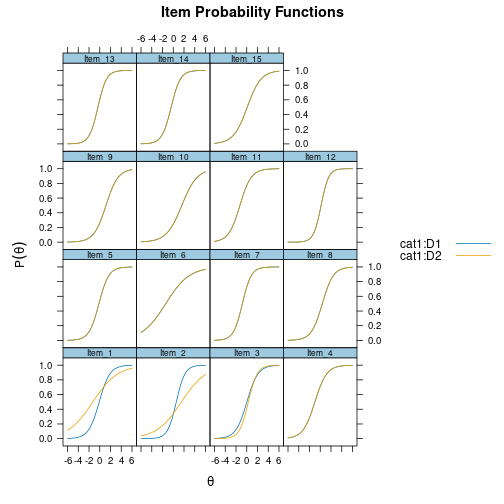

```r
plot(updated_mod, type='trace')
```

```r
###################################
# Multi-group example

a1 <- a2 <- a3 <- matrix(abs(rnorm(15,1,.3)), ncol=1)
d1 <- d2 <- d3 <- matrix(rnorm(15,0,.7),ncol=1)
a2[1:2, ] <- a1[1:2, ]/3
d3[c(1,3), ] <- d2[c(1,3), ]/4
head(data.frame(a.group1 = a1, a.group2 = a2, a.group3 = a3,
                d.group1 = d1, d.group2 = d2, d.group3 = d3))
```

```
##    a.group1  a.group2  a.group3   d.group1   d.group2   d.group3
## 1 0.9921262 0.3307087 0.9921262 -0.6923662 -0.6923662 -0.1730916
## 2 0.6115843 0.2038614 0.6115843 -0.4398444 -0.4398444 -0.4398444
## 3 1.0571399 1.0571399 1.0571399  0.5243734  0.5243734  0.1310934
## 4 1.1508422 1.1508422 1.1508422 -1.0133952 -1.0133952 -1.0133952
## 5 1.2447020 1.2447020 1.2447020 -0.4542548 -0.4542548 -0.4542548
## 6 0.6518627 0.6518627 0.6518627  0.7766470  0.7766470  0.7766470
```

```r
itemtype <- rep('2PL', nrow(a1))
N <- 1000
dataset1 <- simdata(a1, d1, N, itemtype)
dataset2 <- simdata(a2, d2, N, itemtype, mu = .1, sigma = matrix(1.5))
dataset3 <- simdata(a3, d3, N, itemtype, mu = .2)
dat <- rbind(dataset1, dataset2, dataset3)
group <- gl(3, N, labels = c('g1', 'g2', 'g3'))

# equate the groups by assuming the last 5 items have no DIF
itemnames <- colnames(dat)
model <- multipleGroup(dat, group=group, SE=TRUE,
   invariance = c(itemnames[11:ncol(dat)], 'free_means', 'free_var'))
coef(model, simplify=TRUE)
```

```
## $g1
## $items
##            a1      d g u
## Item_1  0.982 -0.707 0 1
## Item_2  0.571 -0.458 0 1
## Item_3  0.991  0.557 0 1
## Item_4  1.240 -1.133 0 1
## Item_5  1.095 -0.475 0 1
## Item_6  0.711  0.712 0 1
## Item_7  0.952 -1.641 0 1
## Item_8  0.709 -0.568 0 1
## Item_9  1.131  0.736 0 1
## Item_10 1.211  0.397 0 1
## Item_11 1.089 -0.384 0 1
## Item_12 0.523 -1.044 0 1
## Item_13 0.983  0.345 0 1
## Item_14 0.950  0.330 0 1
## Item_15 1.292 -0.246 0 1
##
## $means
## F1
##  0
##
## $cov
##    F1
## F1  1
##
##
## $g2
## $items
##            a1      d g u
## Item_1  0.286 -0.788 0 1
## Item_2  0.080 -0.397 0 1
## Item_3  0.898  0.505 0 1
## Item_4  1.025 -0.994 0 1
## Item_5  1.023 -0.364 0 1
## Item_6  0.717  0.832 0 1
## Item_7  1.100 -1.903 0 1
## Item_8  0.783 -0.487 0 1
## Item_9  0.956  0.820 0 1
```

[output cut: 27 more lines]

```
## Item_9  1.227  0.945 0 1
## Item_10 1.344  0.540 0 1
## Item_11 1.089 -0.384 0 1
## Item_12 0.523 -1.044 0 1
## Item_13 0.983  0.345 0 1
## Item_14 0.950  0.330 0 1
## Item_15 1.292 -0.246 0 1
##
## $means
##    F1
## 0.189
##
## $cov
##       F1
## F1 0.893
```

```r
# omnibus tests
dif <- DIF(model, which.par = c('a1', 'd'), items2test=1:9)
dif
```

```
##          groups converged      AIC   SABIC      HQ     BIC      X2 df     p
## Item_1 g1,g2,g3      TRUE -100.312 -88.996 -91.670 -76.286 108.312  4     0
## Item_2 g1,g2,g3      TRUE  -39.696 -28.380 -31.054 -15.670  47.696  4     0
## Item_3 g1,g2,g3      TRUE   -8.644   2.672  -0.002  15.382  16.644  4 0.002
## Item_4 g1,g2,g3      TRUE    4.559  15.875  13.201  28.584   3.441  4 0.487
## Item_5 g1,g2,g3      TRUE    3.087  14.402  11.728  27.112   4.913  4 0.296
## Item_6 g1,g2,g3      TRUE    5.556  16.872  14.198  29.581   2.444  4 0.655
## Item_7 g1,g2,g3      TRUE    4.844  16.160  13.486  28.869   3.156  4 0.532
## Item_8 g1,g2,g3      TRUE    4.504  15.819  13.145  28.529   3.496  4 0.478
## Item_9 g1,g2,g3      TRUE    2.263  13.578  10.904  26.288   5.737  4  0.22
```

```r
# pairwise post-hoc tests for items flagged via omnibus tests
dif.posthoc <- DIF(model, which.par = c('a1', 'd'), items2test=1:2,
                   pairwise = TRUE)
dif.posthoc
```

```
##     item groups converged     AIC   SABIC      HQ     BIC     X2 df     p
## 1 Item_1  g1,g2      TRUE -32.488 -26.830 -28.167 -20.475 36.488  2     0
## 2 Item_2  g1,g2      TRUE -19.000 -13.342 -14.679  -6.988     23  2     0
## 3 Item_1  g1,g3      TRUE -19.543 -13.885 -15.222  -7.530 23.543  2     0
## 4 Item_2  g1,g3      TRUE   1.728   7.385   6.048  13.740  2.272  2 0.321
## 5 Item_1  g2,g3      TRUE -90.300 -84.642 -85.979 -78.287   94.3  2     0
## 6 Item_2  g2,g3      TRUE -36.756 -31.098 -32.435 -24.743 40.756  2     0
```

```r
# further probing for df = 1 tests, this time with Wald tests
DIF(model, which.par = c('a1'), items2test=1:2, pairwise = TRUE,
    Wald=TRUE)
```

```
##     item groups      W df     p
## 1 Item_1  g1,g2 29.897  1     0
## 2 Item_2  g1,g2 22.022  1     0
## 3 Item_1  g1,g3  0.076  1 0.783
## 4 Item_2  g1,g3  1.939  1 0.164
## 5 Item_1  g2,g3 27.618  1     0
## 6 Item_2  g2,g3 30.587  1     0
```

```r
DIF(model, which.par = c('d'), items2test=1:2, pairwise = TRUE,
    Wald=TRUE)
```

```
##     item groups      W df     p
## 1 Item_1  g1,g2  0.592  1 0.442
## 2 Item_2  g1,g2  0.419  1 0.518
## 3 Item_1  g1,g3 21.130  1     0
## 4 Item_2  g1,g3  0.025  1 0.874
## 5 Item_1  g2,g3 29.742  1     0
## 6 Item_2  g2,g3  0.182  1 0.669
```

```r
## End(No test)
```

[Package *mirt* version 1.43 Index]